# tweet_length_project

## Tweets length distribution for different languages (250000 tweets per language)

This notebook is a little example of using Python for data visualization. Data is collected from Twitter, using the twitter streaming API, 250 thousand tweets for each language (english, french, german, spanish, portuguese) were collected.

```python
from wordcloud import WordCloud, STOPWORDS  # package used to generate word clouds
from pylab import rcParams
from PIL import Image
from mpl_toolkits.mplot3d import Axes3D
import matplotlib.pyplot as plt
import seaborn as sns
import numpy as np
import itertools
import json

# this is needed to show plots here in the noteobook
%matplotlib inline
rcParams['figure.figsize'] = 15, 10  # this is the size of each figure
```

#### We collected and preprocessed the data. The files "twitter_data_lang_lengths.txt" contains for each line, the length of the corresponding tweet. The files "twitter_data_lang.txt" contains for each line, a json string representing the tweet.

#### We first write a function to show an histogram of the length distribution using [seaborn](https://stanford.edu/~mwaskom/software/seaborn/index.html).

#### We should expect that a majority of people write tweets of the same length *approximately*, and that a few people will diverge from this mean, writing longer or shorter tweets. In other words, we should expect the length distribution to be approximately Gaussian. Let's see if this is true.

```python
def show_lengths_histogram(filename, lang):

    tweet_lengths = []
    with open(filename, "r") as f:
        for line in f:
            tweet_lengths.append(int(line[0:-1]))
        tweet_lengths.sort()

    sns.distplot(tweet_lengths, color="dodgerblue", bins=30)
    plt.title(lang + " tweets length distribution")
    plt.xlabel("Length")
    sns.despine()
    plt.ylabel("Number of tweets")

    return tweet_lengths
```

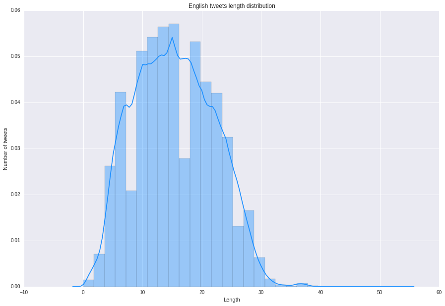

```python
tweet_lengths_en = show_lengths_histogram("twitter_data_en_lengths.txt", "English")
```

```python
print "English tweets average length:"
print np.average(tweet_lengths_en)
```

```
English tweets average length:
15.342976
```

### We'll do the same for the other languages. We should expect more or less the same outcome as the english language

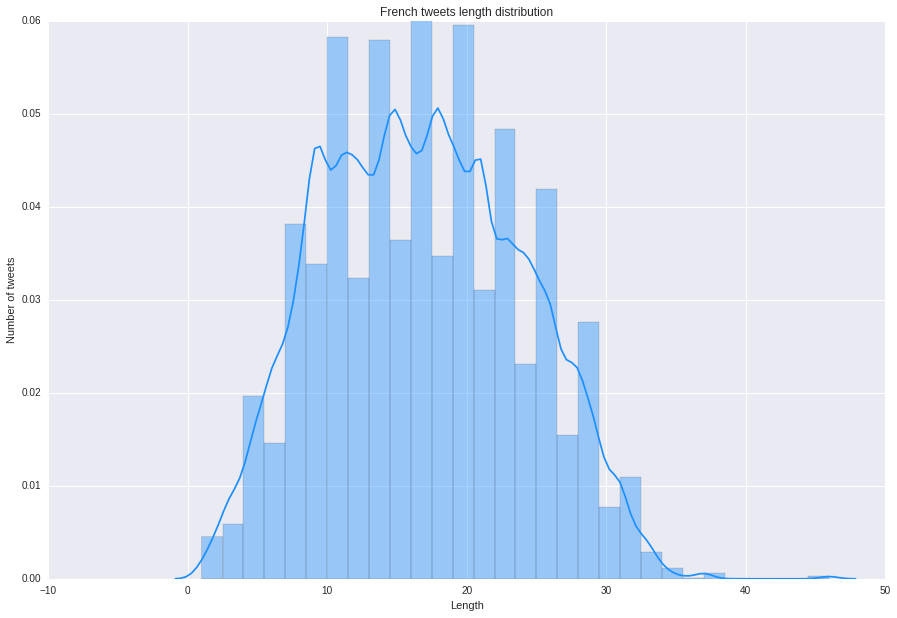

```python
tweet_lengths_fr = show_lengths_histogram("twitter_data_fr_lengths.txt", "French")
```

```python
print "French tweets average length:"
print np.average(tweet_lengths_fr)
```

```
French tweets average length:
16.811384
```

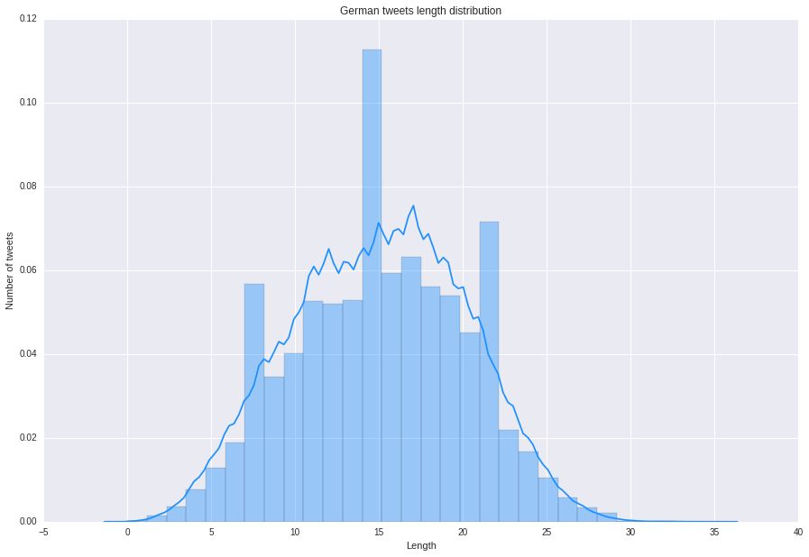

```python
tweet_lengths_de = show_lengths_histogram("twitter_data_de_lengths.txt", "German")
```

```python
print "German tweets average length:"
print np.average(tweet_lengths_de)
```

```
German tweets average length:
15.022236
```

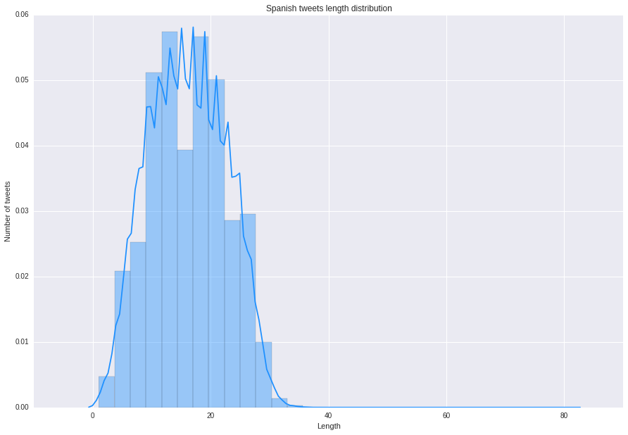

```python
tweet_lengths_es = show_lengths_histogram("twitter_data_es_lengths.txt", "Spanish")
```

```python
print "Spanish tweets average length:"
print np.average(tweet_lengths_es)
```

```
Spanish tweets average length:
16.057196
```

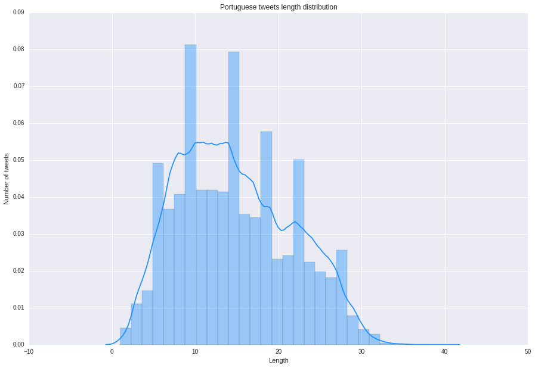

```python
tweet_lengths_pt = show_lengths_histogram("twitter_data_pt_lengths.txt", "Portuguese")
```

```python
print "Portoguese tweets average length:"
print np.average(tweet_lengths_pt)
```

[output not shown]

### Let's get the overall picture by showing a 3D plot showing the above plots together.

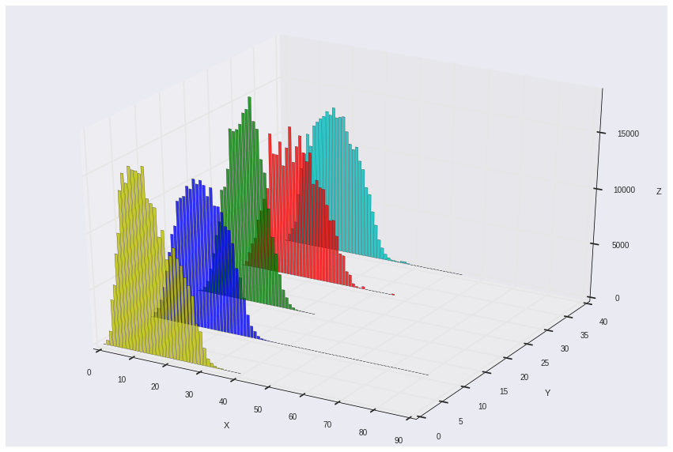

```python
fig = plt.figure()
data=[tweet_lengths_en, tweet_lengths_fr, tweet_lengths_de, tweet_lengths_es, tweet_lengths_pt]
i=0
max_y=0
ax = fig.add_subplot(111, projection='3d')
for c, z in zip(['c','r', 'g', 'b', 'y'], [40,30, 20, 10, 0]):
    xs = np.arange(0,max(data[i])+1)
    ys=[]
    for x in range(0,max(data[i])+1):
        y=data[i].count(x)
        ys.append(y)
        max_y=max(max_y,y)

    ys=np.array(ys)

    # You can provide either a single color or an array. To demonstrate this,
    # the first bar of each set will be colored cyan.
    cs = [c] * len(xs)
    cs[0] = 'c'
    ax.bar(xs, ys, zs=z, zdir='y', color=cs, alpha=0.8)
    i+=1


ax.set_xlabel('X')
ax.set_ylabel('Y')
ax.set_zlabel('Z')
ax.set_zlim([0,max_y])

plt.show()
```

### Yeah, 3D is always cooler.

#### Now let's visualize the words. We'll create a words cloud for each language, using the wordcloud package.

### Bonus feature: the clouds will have the shape of the twitter logo!

```python
def load_long_text(filename):

    text = []

    with open(filename, 'r') as data_en:
        lines = data_en.readlines()

    for line in lines:
        tweet = json.loads(line)
        text.append(tweet['text'] + " ")

    return ''.join(text)
```

```python
en_tweets_text = load_long_text('twitter_data_en.txt')
```

```python
fr_tweets_text = load_long_text('twitter_data_fr.txt')
```

```python
de_tweets_text = load_long_text('twitter_data_de.txt')
```

```python
es_tweets_text = load_long_text('twitter_data_es.txt')
```

```python
pt_tweets_text = load_long_text('twitter_data_pt.txt')
```

```python
def show_words_cloud(text):
    twitter_mask = np.array(Image.open("twitter_logo_mask.png"))

    wcloud = WordCloud(background_color="white", max_words=200,
                       mask=twitter_mask, max_font_size=60,
                       stopwords=STOPWORDS.add("RT"))

    wcloud.generate(text)

    plt.figure()
    plt.imshow(wcloud)
    plt.axis("off")
    plt.show()
```

[figure not shown]

```python
show_words_cloud(en_tweets_text)
```

[figure not shown]

```python
show_words_cloud(fr_tweets_text)
```

[figure not shown]

```python
show_words_cloud(de_tweets_text)
```

[figure not shown]

```python
show_words_cloud(es_tweets_text)
```

[figure not shown]

```python
show_words_cloud(pt_tweets_text)
```